# LM: Point estimates

2018-05-15

## The Linear Model: LM

- 2.0 Introduction
- 2.1 Point estimates
- 2.2 Uncertainty in point estimates
- 2.3 Tests
- 2.4 Assumptions and Outliers
- 2.5 Let's practice more

## You will learn in this session

- what predictions, estimates and residuals are
- that the variance of residuals is a biased estimator of the error variance
- how to compute estimates numerically in a few lines of code
- how `lm()` works
- what the components stored within `lm()` objects are

## Introduction

## Let's simulate more Alien data

### Imagine an ideal (unrealistic) situation

We know that the process generating the height of aliens can be approximated by the following linear model:

- \(\texttt{height}_i = 50 + 1.5 \times \texttt{humans_eaten}_{i} + \epsilon_i\)
- \(\epsilon_i \sim \mathcal{N}(0, \sigma^2 = 25)\)

We generate the data corresponding to 12 aliens that have eaten between 1 and 12 humans.

```r
set.seed(123L)
Alien <- data.frame(humans_eaten = sample(1:12))
Alien$size <- rnorm(n = 12, mean = 50 + 1.5*Alien$humans_eaten, sd = sqrt(25))
```

## In reality, model parameters are unknown, so we will have to estimate them!

(that is the whole point of statistical modelling…)

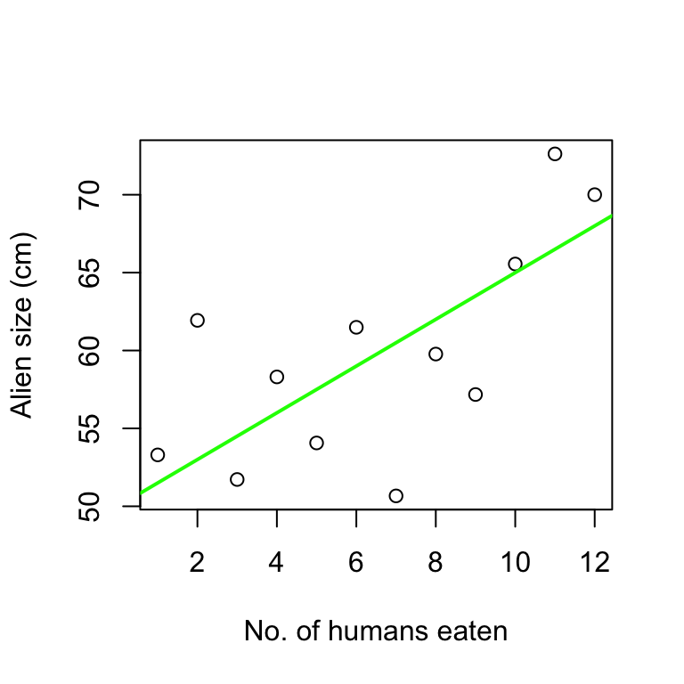

True relationship

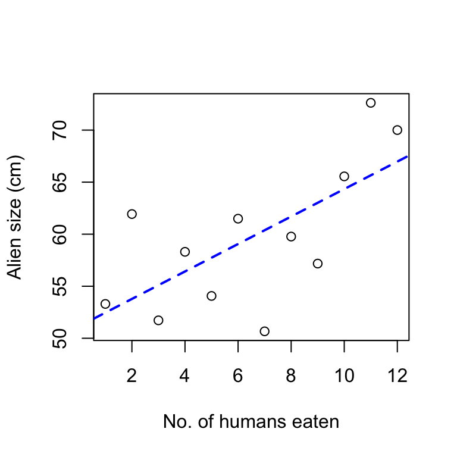

Inferred relationship

## Fitting the model to the data…

### … means estimating the values of the model parameters that maximise the probability of the data.

### Why fitting?

### For drawing inferences about population processes (i.e. about what you could observe in other samples).

## Notations

## Mathematical notation of LM fits

### Simple notation

\(\hat{y_i} = \hat{\beta_0} + \hat{\beta_1} \times x_{1,i} + \hat{\beta_2} \times x_{2,i} + \dots + \hat{\beta_p} \times x_{p,i}\)

- \(x_{j,i}\) = constants derived from the predictors / explanatory variables / independent variables
- \(\hat{y_i}\) = the predictions / predicted values
- \(\hat{\beta_j}\) = the (model parameter / regression coefficient) estimates
- \(y_i - \hat{y_i} = \varepsilon_i\) = the residuals (i.e. the estimates for the errors)

### Matrix notation

\(\widehat{Y} = X \widehat{\beta}\)

\(Y = X \widehat{\beta} + \varepsilon = \widehat{Y} + \varepsilon\)

\(\varepsilon = \widehat{\epsilon} = Y - \widehat{Y}\)

## Fitting procedure

## How to fit a LM?

### By maximum likelihood

We want to find the \(\widehat{\beta}\) maximizing the likelihood.

The likelihood of the model given the data is equal to the probability density assumed for those data given those parameter values, that is: \(\displaystyle {\mathcal {L}}(\theta \mid x) = P(x \mid \theta)\).

### In LM, this is equivalent to performing the estimation by

### ordinary least squares (OLS)

We want to find the \(\widehat{\beta}\) minimizing the residual sum of squares (RSS).

The RSS = \(\displaystyle\sum_{i=1}^{n}{\varepsilon_i^2}\).

## Fitting the Alien data using `lm()` as a black box

```r
(mod_alien_lm <- lm(size ~ humans_eaten, data = Alien))
```

```
##
## Call:
## lm(formula = size ~ humans_eaten, data = Alien)
##
## Coefficients:
##  (Intercept)  humans_eaten
##        51.14          1.32
```

```r
names(mod_alien_lm)
```

```
##  [1] "coefficients"  "residuals"     "effects"       "rank"          "fitted.values" "assign"        "qr"
##  [8] "df.residual"   "xlevels"       "call"          "terms"         "model"
```

We will see what all these components are!

## We can extract all kind of information from the fit

```r
(coef_lm <- mod_alien_lm$coef) ## We expect something close to 50 and 1.5
```

```
##  (Intercept) humans_eaten
##    51.139816     1.319579
```

```r
summary(mod_alien_lm)$sigma^2 ## We expect something close to 25
```

```
## [1] 29.28664
```

```r
logLik(mod_alien_lm)[1]
```

```
## [1] -36.19612
```

```r
anova(mod_alien_lm)$"Sum Sq"[2]
```

```
## [1] 292.8664
```

## Reverse engineering the LM fit

## Recovering the design matrix

```r
X_alien <- model.matrix(mod_alien_lm)  ## Tip: same as model.matrix(~ humans_eaten, data = Alien)
head(X_alien)
```

```
##   (Intercept) humans_eaten
## 1           1            4
## 2           1            9
## 3           1            5
## 4           1            8
## 5           1           11
## 6           1            1
```

## Recovering the predicted values

```r
pred_auto   <- predict(mod_alien_lm)  ## Tip: same as mod_alien_lm$fitted.values / fitted(mod_alien_lm)
pred_auto2  <- predict(mod_alien_lm, newdata = Alien) ## can handle missing data!
pred_simple <- coef_lm[1] + coef_lm[2] * Alien$humans_eaten
pred_matrix <- X_alien %*% coef_lm
```

All four methods are identical!

```r
head(cbind("auto" = pred_auto, "auto2" = pred_auto2, "simple" = pred_simple, "matrix" = c(pred_matrix)))
```

```
##       auto    auto2   simple   matrix
## 1 56.41813 56.41813 56.41813 56.41813
## 2 63.01603 63.01603 63.01603 63.01603
## 3 57.73771 57.73771 57.73771 57.73771
## 4 61.69645 61.69645 61.69645 61.69645
## 5 65.65519 65.65519 65.65519 65.65519
## 6 52.45940 52.45940 52.45940 52.45940
```

```r
Alien$pred <- pred_auto ## we store the predicts in the dataframe
```

## Recovering the residuals

```r
resid_auto   <- residuals(mod_alien_lm)  ## Tip: same as mod_alien_lm$residuals
resid_simple <- Alien$size - (coef_lm[1] + coef_lm[2] * Alien$humans_eaten)
resid_matrix <- matrix(Alien$size) - X_alien %*% coef_lm
```

```r
head(cbind("auto" = resid_auto, "simple" = resid_simple, "matrix" = c(resid_matrix)))
```

```
##        auto    simple    matrix
## 1  1.886448  1.886448  1.886448
## 2 -5.841336 -5.841336 -5.841336
## 3 -3.671977 -3.671977 -3.671977
## 4 -1.924760 -1.924760 -1.924760
## 5  6.965221  6.965221  6.965221
## 6  0.839674  0.839674  0.839674
```

```r
Alien$resid <- resid_auto ## we store the residuals in the dataframe
```

## Recovering the Residual Sum of Squares

```r
(rss_lm <- anova(mod_alien_lm)$"Sum Sq"[2])
```

```
## [1] 292.8664
```

```r
sum(Alien$resid^2)
```

```
## [1] 292.8664
```

## The Residual Sum of Squares (RSS)

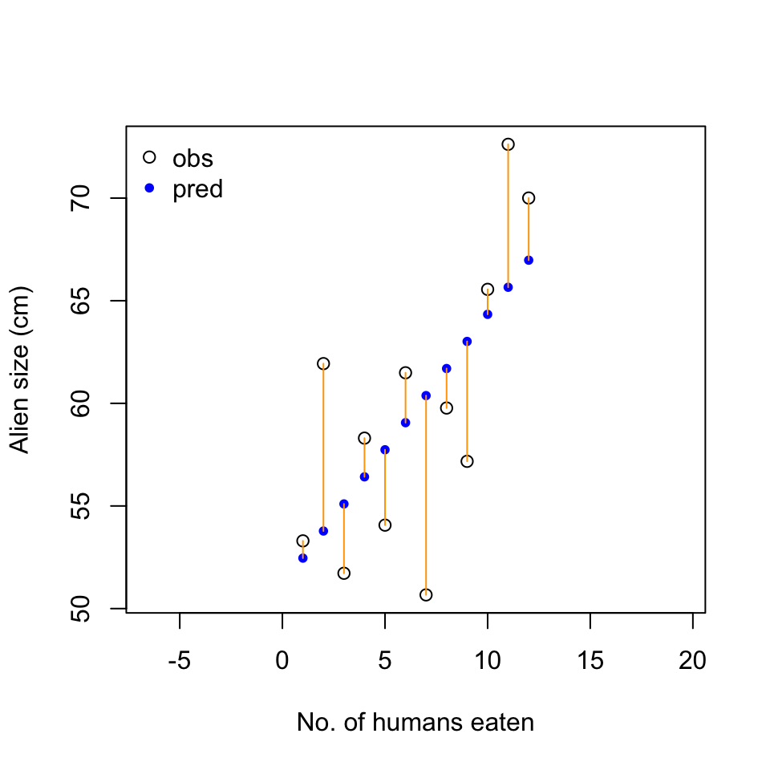

Residuals on best fit

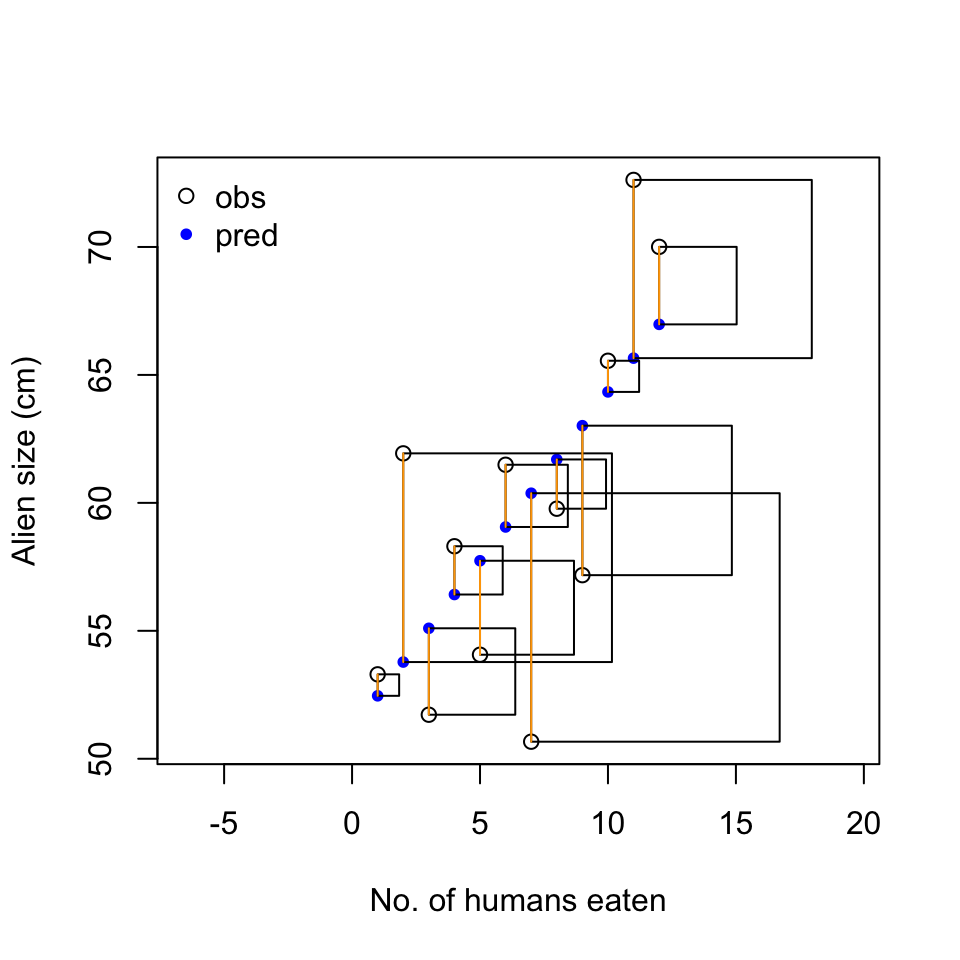

Squared residuals on best fit

## The Residual Sum of Squares (RSS)

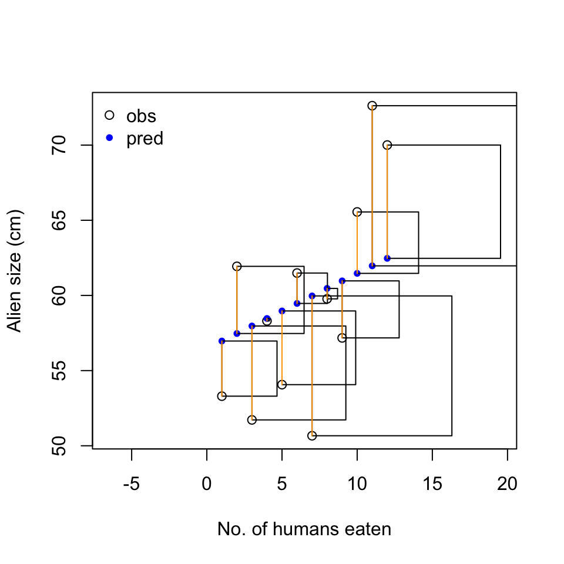

Squared residuals on bad fit

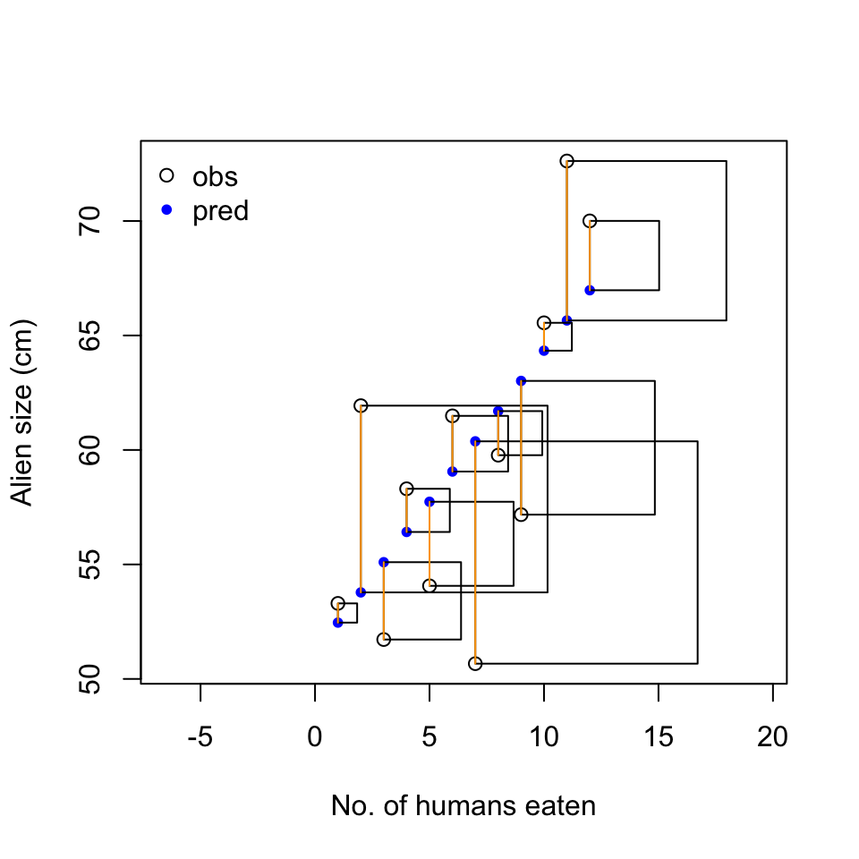

Squared residuals on best fit

## Recovering the estimate of the error variance

```r
(sigma2_error <- summary(mod_alien_lm)$sigma^2)
```

```
## [1] 29.28664
```

```r
sum(Alien$resid^2) / (nrow(Alien) - length(coef_lm))
```

```
## [1] 29.28664
```

```r
deviance(mod_alien_lm)/mod_alien_lm$df.residual
```

```
## [1] 29.28664
```

```r
var(Alien$resid) * (nrow(Alien) - 1) / (nrow(Alien) - length(coef_lm))
```

```
## [1] 29.28664
```

## Recovering the variance of the residuals

```r
(sigma2_resid <- sum(Alien$resid^2) / nrow(Alien))
```

```
## [1] 24.40553
```

```r
deviance(mod_alien_lm) / nrow(Alien)
```

```
## [1] 24.40553
```

```r
var(Alien$resid) * (nrow(Alien) - 1) / nrow(Alien)
```

```
## [1] 24.40553
```

```r
sigma2_error * (nrow(Alien) - length(coef_lm)) /  nrow(Alien)
```

```
## [1] 24.40553
```

Note: we observe it; this is not an estimate.

## Recovering the max (log-)likelihood

```r
Alien$density <- dnorm(x = Alien$size, mean = Alien$pred, sd = sqrt(sigma2_resid))
Alien[1, ]
```

```
##   humans_eaten     size     pred    resid    density
## 1            4 58.30458 56.41813 1.886448 0.07507626
```

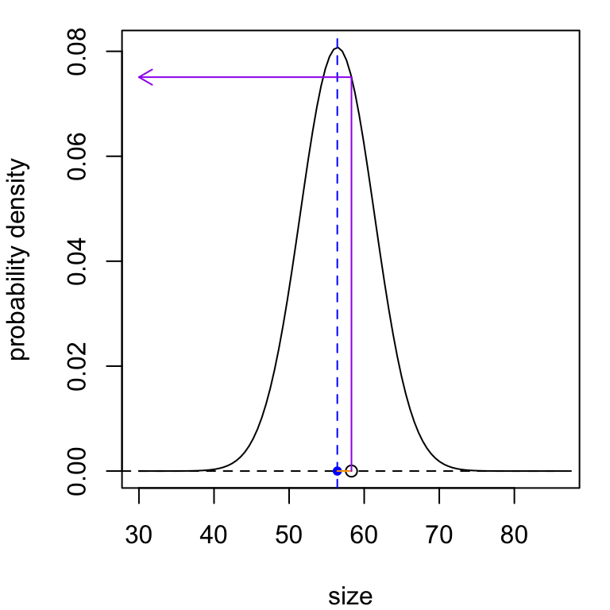

```r
logLik(mod_alien_lm)[1]
```

```
## [1] -36.19612
```

```r
log(prod(Alien$density))
```

```
## [1] -36.19612
```

```r
sum(log(Alien$density))
```

```
## [1] -36.19612
```

## Recovering the deviance

```r
deviance(mod_alien_lm)
```

```
## [1] 292.8664
```

```r
(logLik_mod <- logLik(mod_alien_lm))
```

```
## 'log Lik.' -36.19612 (df=3)
```

```r
(logLik_sat <- sum(dnorm(Alien$size, mean = Alien$size, sd = sqrt(sigma2_resid), log = TRUE)))
```

```
## [1] -30.19612
```

```r
(-2 * sigma2_resid * (logLik_mod - logLik_sat))  ## definition of the unscaled deviance!!!
```

```
## 'log Lik.' 292.8664 (df=3)
```

Note: the deviance is in LM equal to the residual sum of squares!

## Recovering the estimates numerically by Maximum Likelihood (ML)

```r
compute_logLik <- function(vector.param, formula, data) {
  useful.data <- model.frame(formula = formula, data = data)
  X <- model.matrix(object = formula, data = useful.data)
  predicts <- X %*% matrix(vector.param)
  response <- model.response(useful.data)
  sigma2_resid <- sum((response - predicts)^2) / nrow(useful.data)
  logL <- sum(dnorm(response, mean = predicts, sd = sqrt(sigma2_resid), log = TRUE))
  return(logL)
}

(theta.lm <- c("intercept" = coef_lm[1][[1]], "slope" = coef_lm[2][[1]])) ## For testing
```

```
## intercept     slope
## 51.139816  1.319579
```

```r
compute_logLik(vector.param = theta.lm, formula = size ~ humans_eaten, data = Alien)
```

```
## [1] -36.19612
```

## Recovering the estimates numerically by Maximum Likelihood (ML)

### We look for the estimates yielding the maximum likelihood

```r
result_opt <- optim(c("intercept" = 0, "slope" = 1), compute_logLik,
                    formula = size ~ humans_eaten, data = Alien,
                    control = list(fnscale = -1))
result_opt$par
```

```
## intercept     slope
## 51.141382  1.319268
```

```r
result_opt$value
```

```
## [1] -36.19612
```

## Recovering the estimates numerically by Ordinary Least Squares (OLS)

```r
compute_rss <- function(vector.param, formula, data) {
  useful.data <- model.frame(formula = formula, data = data)
  X <- model.matrix(object = formula, data = useful.data)
  predicts <- X %*% matrix(vector.param)
  response <- model.response(useful.data)
  rss <- sum((response - predicts)^2)
  return(rss)
}

compute_rss(vector.param = theta.lm, formula = size ~ humans_eaten, data = Alien)  ## For testing
```

```
## [1] 292.8664
```

```r
optim(c("intercept" = 0, "slope" = 1), compute_rss, formula = size ~ humans_eaten, data = Alien)$par
```

```
## intercept     slope
## 51.147002  1.318594
```

## Comparing the three methods on a real dataset

```r
time1 <- system.time(mod_test_lm <- lm(height ~ weight*sex + cigarettes + drink, data = UK))

time2 <- system.time(mod_test_alexML <- optim(rep(0, 8), compute_logLik,
                    formula = height ~ weight*sex + cigarettes + drink, data = UK,
                    control = list(fnscale = -1), method = "BFGS"))  ## default optim method is getting lost...

time3 <- system.time(mod_test_alexRSS <- optim(rep(0, 8), compute_rss,
                    formula = height ~ weight*sex + cigarettes + drink,
                    data = UK, method = "BFGS"))

round(rbind(c(coef(mod_test_lm), time1[1]), c(mod_test_alexML$par, time2[1]), c(mod_test_alexML$par, time3[1])), 2)
```

```
##      (Intercept) weight sexGirl cigarettes drinkMost days drinkNot at all drinkOnce a week or less weight:sexGirl
## [1,]      113.18   0.82    2.22      -0.03          -0.17           -0.62                    -0.14          -0.09
## [2,]      113.18   0.82    2.22      -0.03          -0.17           -0.62                    -0.14          -0.09
## [3,]      113.18   0.82    2.22      -0.03          -0.17           -0.62                    -0.14          -0.09
##      user.self
## [1,]      0.03
## [2,]      8.17
## [3,]      2.52
```

## Recovering the estimates analytically

\(\widehat{\beta} = (X^\text{T}X)^{-1}X^\text{T}Y\)

(see wikipedia for demonstration)

### This gives best estimates directly:

```r
Y <- matrix(Alien$size)
X <- model.matrix(mod_alien_lm)
solve(t(X) %*% X) %*% t(X) %*% Y  ## Tip: solve(x) returns the inverse of the matrix x
```

```
##                   [,1]
## (Intercept)  51.139816
## humans_eaten  1.319579
```

… but `lm()` does not do that because it is somewhat inefficient.

Note: \(\widehat{Y} = X \widehat{\beta} = X (X^TX)^{-1}X^TY=HY\), and \(H\) is called the hat matrix (it is a projection matrix).

## Recovering the estimates analytically using the QR decomposition

The goal is simply to decompose the design matrix into a product of two new matrices that present nice properties for doing math more efficiently.

```r
qr_list <- qr(X)  ## same as mod_alien_lm$qr
Q <- qr.Q(qr_list, complete = TRUE)  ## orthogonal matrix n * n (transpose = inverse)
R <- qr.R(qr_list, complete = TRUE)  ## upper triangular matrix n * p
```

```r
all.equal(Q %*% R, X, check.attributes = FALSE)  ## TRUE: Q %*% R is equal to X!!
```

[output not shown]

```r
QTY <- t(Q) %*% Y    ## same as mod_alien_lm$effects
backsolve(R, QTY)    ## RB = QTY, solve B for triangular matrix (more efficient than solve(R[1:2, 1:2], QTY[1:2]))
```

```
##           [,1]
## [1,] 51.139816
## [2,]  1.319579
```

- Note 1: \(Q^\text{T}Y\) is also used to compute sum of squares efficiently in e.g. `anova()`.
- Note 2: other decompositions are sometimes used (e.g. Cholesky).

## Dissecting the output from `lm()`

```r
names(mod_alien_lm)
```

```
##  [1] "coefficients"  "residuals"     "effects"       "rank"          "fitted.values" "assign"        "qr"
##  [8] "df.residual"   "xlevels"       "call"          "terms"         "model"
```

We have already seen all non-trivial components!

We have not yet seen:

- `rank`: the number of columns that are linearly independent in the design matrix.
- `assign`: it comes from `attr(X, "assign")`; it indicates which parameters belong to each covariate.
- `df.residuals`: nrow(Alien) - rank.
- `xlevels`: here, empty.
- `call`: the clean function call to `lm()`.
- `terms`: an object of class terms; i.e. the formula with many attributes (`?terms.object`).
- `model`: it comes from `model.frame()`; it gives the data used for the fit.

## The guts of `lm()`

First, `lm()` processes information for `lm.fit()`

```r
lm(size ~ humans_eaten, data = Alien)
mf <- model.frame(size ~ humans_eaten, data = Alien)
Y  <- model.response(mf)
X  <- model.matrix(~ humans_eaten, data = Alien)
lm.fit(X, Y)
```

Then, `lm.fit()` calls a C function (Cdqrls) that calls a Fortran function (dqrls, which will compute estimates after QR) calling another Fortran function (dqrdc2, which performs the QR decomposition).

```
C     Dqrdc2 is a *modification* of Linpack's dqrdc ('DQRDC') for R
c
c     dqrdc2 uses householder transformations to compute the qr
c     factorization of an n by p matrix x.  a limited column
c     pivoting strategy based on the 2-norms of the reduced columns
c     moves columns with near-zero norm to the right-hand edge of
c     the x matrix.  this strategy means that sequential one
c     degree-of-freedom effects can be computed in a natural way.
c
c     i am very nervous about modifying linpack code in this way.
c     if you are a computational linear algebra guru and you really
c     understand how to solve this problem please feel free to
c     suggest improvements to this code.
```

## Interpreting estimates

## The UK dataset

```r
head(UK)
```

```
##    sex  age weight height glasses cigarettes_mum cigarettes_dad cigarettes cigarettes_kid cigarettes_friends bronchitis
## 1 Girl 3660   29.4  134.5      No              0              0          0          Never       None of them          0
## 2  Boy 3841   31.6  141.0      No             20              0         20          Never       None of them          0
## 3  Boy 3675   34.9  143.0    <NA>             20              0         20          Never       None of them          0
## 4 Girl 3694   30.2  139.7      No              0              0          0          Never       None of them          0
## 5 Girl 3742     NA     NA    <NA>              0              0          0          Never       None of them          0
## 6  Boy 3671   24.6  128.0      No             15              0         15     Tried once       None of them          0
##                 drink milk coca backward mother_height father_height mother_weight father_weight
## 1 Once a week or less    0    0       20           157           168            51            79
## 2          Not at all    1    1       16           157            NA            51            NA
## 3 Once a week or less    3    1        4           155           175            50            72
## 4 Once a week or less    0    0       12           160            NA            63            NA
## 5                <NA>    0    0       NA            NA            NA            NA            NA
## 6          Not at all    3    0       14           155           173            50            76
```

```r
mod_UK1 <- lm(height ~ drink + sex*weight, data = UK)
```

## Model frame of `mod_UK1`

```r
mf <- mod_UK1$model
str(mf)
```

```
## 'data.frame':    11232 obs. of  4 variables:
##  $ height: num  134 141 143 140 128 ...
##  $ drink : Factor w/ 4 levels "2 to 3 times a week",..: 4 3 4 4 3 3 4 1 4 4 ...
##  $ sex   : Factor w/ 2 levels "Boy","Girl": 2 1 1 2 1 2 2 2 1 1 ...
##  $ weight: num  29.4 31.6 34.9 30.2 24.6 40.8 29.9 25.6 29.1 37.5 ...
##  - attr(*, "terms")=Classes 'terms', 'formula'  language height ~ drink + sex * weight
##   .. ..- attr(*, "variables")= language list(height, drink, sex, weight)
##   .. ..- attr(*, "factors")= int [1:4, 1:4] 0 1 0 0 0 0 1 0 0 0 ...
##   .. .. ..- attr(*, "dimnames")=List of 2
##   .. .. .. ..$ : chr [1:4] "height" "drink" "sex" "weight"
##   .. .. .. ..$ : chr [1:4] "drink" "sex" "weight" "sex:weight"
##   .. ..- attr(*, "term.labels")= chr [1:4] "drink" "sex" "weight" "sex:weight"
##   .. ..- attr(*, "order")= int [1:4] 1 1 1 2
##   .. ..- attr(*, "intercept")= int 1
##   .. ..- attr(*, "response")= int 1
##   .. ..- attr(*, ".Environment")=<environment: R_GlobalEnv>
##   .. ..- attr(*, "predvars")= language list(height, drink, sex, weight)
##   .. ..- attr(*, "dataClasses")= Named chr [1:4] "numeric" "factor" "factor" "numeric"
##   .. .. ..- attr(*, "names")= chr [1:4] "height" "drink" "sex" "weight"
##  - attr(*, "na.action")=Class 'omit'  Named int [1:3643] 5 13 14 19 23 41 43 46 51 52 ...
##   .. ..- attr(*, "names")= chr [1:3643] "5" "13" "14" "19" ...
```

## Model frame of `mod_UK1`

```r
head(mf)
```

```
##   height               drink  sex weight
## 1  134.5 Once a week or less Girl   29.4
## 2  141.0          Not at all  Boy   31.6
## 3  143.0 Once a week or less  Boy   34.9
## 4  139.7 Once a week or less Girl   30.2
## 6  128.0          Not at all  Boy   24.6
## 7  140.3          Not at all Girl   40.8
```

## Design matrix of `mod_UK1`

```r
X <- model.matrix(mod_UK1)
head(X)
```

```
##   (Intercept) drinkMost days drinkNot at all drinkOnce a week or less sexGirl weight sexGirl:weight
## 1           1              0               0                        1       1   29.4           29.4
## 2           1              0               1                        0       0   31.6            0.0
## 3           1              0               0                        1       0   34.9            0.0
## 4           1              0               0                        1       1   30.2           30.2
## 6           1              0               1                        0       0   24.6            0.0
## 7           1              0               1                        0       1   40.8           40.8
```

## Practice

### Coefficients of `mod_UK1`

```r
data.frame(coef(mod_UK1))
```

```
##                          coef.mod_UK1.
## (Intercept)              112.480788887
## drinkMost days            -0.029829848
## drinkNot at all           -0.476168314
## drinkOnce a week or less  -0.006905423
## sexGirl                    2.380423974
## weight                     0.821839260
## sexGirl:weight            -0.093667026
```

### What do each of these estimates really mean?

(If you struggle interpreting parameter estimates, try to compute some predictions!)

## Predictions with `mod_UK1`

- height of a 30 Kg boy whose mum drank most days?
- height of a 30 Kg girl whose mum drank most days?
- height of a 35 Kg boy whose mum drank 2 to 3 times a week?

```r
newX <- matrix(
  c(1, 1, 0, 0, 0, 30, 0,
    1, 1, 0, 0, 1, 30, 30,
    1, 0, 0, 0, 0, 35, 0),
  nrow = 3, byrow = TRUE)
colnames(newX) <- names(coef(mod_UK1))
newX
```

```
##      (Intercept) drinkMost days drinkNot at all drinkOnce a week or less sexGirl weight sexGirl:weight
## [1,]           1              1               0                        0       0     30              0
## [2,]           1              1               0                        0       1     30             30
## [3,]           1              0               0                        0       0     35              0
```

## Predictions with `mod_UK1`

- height of a 30 Kg boy whose mum drank most days?
- height of a 30 Kg girl whose mum drank most days?
- height of a 35 Kg boy whose mum drank 2 to 3 times a week?

```r
newX %*% coef(mod_UK1)
```

```
##          [,1]
## [1,] 137.1061
## [2,] 136.6766
## [3,] 141.2452
```

Let's check:

```r
newdata1 <- data.frame(
  drink = c("Most days", "Most days", "2 to 3 times a week"),
  sex = c("Boy", "Girl", "Boy"),
  weight = c(30, 30, 35))
predict(mod_UK1, newdata = newdata1)
```

```
##        1        2        3
## 137.1061 136.6766 141.2452
```

## Practice

### Predict and plot the influence of the weight of girls on their height!

[figure not shown]

(solution)

## Fitting LM with `spaMM`

## For comparison: with `stats`

```r
mod_stats <- lm(size ~ humans_eaten, data = Alien)
coef(mod_stats)
```

```
##  (Intercept) humans_eaten
##    51.139816     1.319579
```

```r
summary(mod_stats)$sigma^2  ## estimate of error variance
```

```
## [1] 29.28664
```

```r
summary(mod_stats)$sigma^2 * (nrow(Alien) - length(coef_lm)) /  nrow(Alien)
```

```
## [1] 24.40553
```

```r
logLik(mod_stats)
```

```
## 'log Lik.' -36.19612 (df=3)
```

## With `spaMM` using ML

```r
library(spaMM)
mod_spaMM_ML <- fitme(size ~ humans_eaten, data = Alien, method = "ML")  ## ML is the default
mod_spaMM_ML$fixef
```

```
##  (Intercept) humans_eaten
##    51.139816     1.319579
```

```r
mod_spaMM_ML$phi ## biased estimate of error variance (= here to residual variance)
```

```
## [1] 24.40553
```

```r
logLik(mod_spaMM_ML)[[1]]
```

```
## [1] -36.19612
```

## With `spaMM` using REML

```r
mod_spaMM_REML <- fitme(size ~ humans_eaten, data = Alien, method = "REML")
mod_spaMM_REML$fixef
```

```
##  (Intercept) humans_eaten
##    51.139816     1.319579
```

```r
mod_spaMM_REML$phi ## unbiased estimate of error variance
```

```
## [1] 29.28664
```

```r
logLik(mod_spaMM_REML)[[1]]
```

```
## [1] -34.79892
```

## What you need to remember

- what predictions, estimates and residuals are
- that the variance of residuals is a biased estimator of the error variance
- how to compute estimates numerically in a few lines of code
- (how `lm()` works)
- (what the components stored within `lm()` objects are)

## Table of contents

## The Linear Model: LM

- 2.0 Introduction
- 2.1 Point estimates
- 2.2 Uncertainty in point estimates
- 2.3 Tests
- 2.4 Assumptions and Outliers
- 2.5 Let's practice more